# hw1

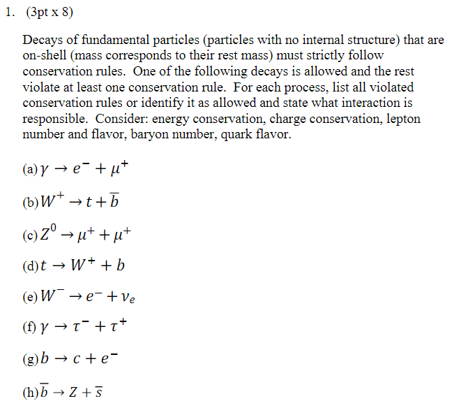

There can be multiple violations in each example, so watch out.

(a) Clearly a violation of lepton flavor. Also, wouldn't an on-shell photon have no energy to contributre to the electron and antimuon mass?

(b) The on-shell $W^+$ boson has less mass than a top quark, so this cannot occur. I think weak interactions don't care about quark flavor conservation

(c) Charge and lepton flavor violation.

(d) Acceptable. Quark flavor is fine due to weak force

(e) Lepton flavor violation. Would be fine if positron or antineutrino.

(f) Energy violation again with an on-shell photon.

(g) quark flavor violation, no weak forces seen here. Also lepton flavor

(h) energy violation, $Z$ is much heavier than $\overline{b}$

Let's identify each of these particles. Mass in GeV/c^2

$\gamma$ photon mass:0 charge:0  
$e^-$ electron mass:0.000511  
$\mu^+$ antimuon mass:0.106

$W^+$ W boson mass:80.39 charge:+1  
$t$ top quark mass:173.1 charge:+2/3  
$\overline{b}$ anti-bottom quark mass:4.18 charge: +1/3

$Z^0$ Z Boson mass:91.19

$b$ bottom quark mass:4.18 charge: -1/3

$W^-$ W boson mass:80.39 charge:-1  
$\nu_e$ electron neutrino mass:small, charge:0

$\tau^-$ tau mass:1.777 charge:-1  
$\tau^+$ tau mass:1.777 charge:+1

$c$ charm quark mass:1.28 charge:+2/3

$\overline{s}$ antistrange quark mass: 0.1 charge:+1/3

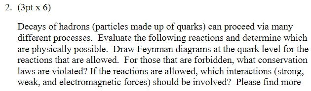

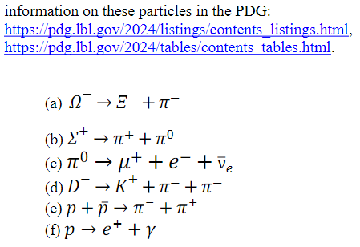

## Incomplete, sorry!

(a) charge violation -1 to -2.

(b) This doesn't work out, where does the strange quark in $\Sigma^+$ has to go somewhere

(c) This fails due to lepton flavor. The neutral pion has no lepton flavor, so there is a net gain of one -1 muon flavor.

(d)

(e) This one works. Since the $\pi^+$ pion is $u\overline{d}$ and the proton is $uud$, there is a $u \overline{u}$ annihilation and the remaining quarks are split up into their pions. The annihilation creates virtual particles (gluons) which the remaining particles absorb. Gluons are necessary to keep the chromodynamics in order.

(f) quark violation, lepton flavor violation. Where do the quarks go?

Hadron descriptions

$\Omega^-$ $sss$ 1.6 GeV/c^2  
$\Xi^-$ $dss$ 1.3 GeV/c^2  
$\pi^-$ $\overline{u} d$ .14 GeV/c^2

$\Sigma^+$ $uus$ 1.2 Gev/c^2  
$\pi^0$ $u\overline{u}$ or $d\overline{d}$ .13 GeV/c^2

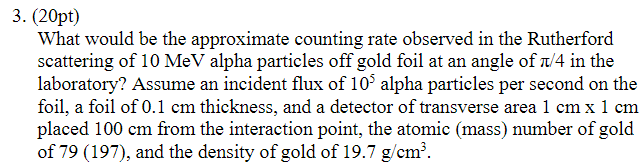

This question asks what the odds are that helium atoms hit gold atoms and scatter at a $45\degree$ angle. Hyperphysics has a pretty good walkthrough of this problem

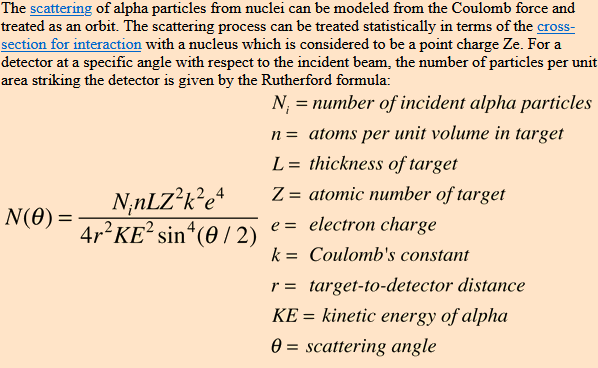

Since this is the rate per unit area, we can either assume the angle is constant across the 1cm x 1cm detector, or do some calculus. I choose the former.

We'll have $N(\theta)$ calculate the rate of particles per unit area rather than the count. Then we have

$$ \text{gold molar mass} = 196.967\ g/mol \\ 19.7\ g/cm^3\ /\ 196.967\ g/mol\ =\ 0.1 mol/cm^3 \\ n = 0.1 * 6.023e23 \ \text{atoms}/cm^3 \\ $$

```python
from scipy.constants import e, epsilon_0, pi, N_A
from numpy import sin

Ni = 1e5
n = 19.7/196.967*N_A #atoms / cm3
L = 0.1 # cm
Z = 79
k = 1/(4*pi*epsilon_0)
r = 100 # cm
KE = 10 * e * 1e6 #MeV to J
theta = pi/4

N = Ni * n * L * Z**2 * k**2 * e**4 / ( 4 * r**2 * KE**2 * (sin(theta/2))**4 )
N
```

```
9.085792346300234e-05
```

That's much smaller than one. Maybe a flux of $10^5$ isn't really a big number. Since our unit area is 1cm x 1cm, this is also the rate which the detector sees. It comes out to one particle every ~3 hours.